# Tutorato 2

2026-03-25

# 1. Esercizio con Dataset

## Parte A: esplorazione del dataset

Vogliamo analizzare il dataset `mtcars` usando le funzioni del pacchetto `dplyr`.

1. Caricare ed esplorare il dataset;
2. Aggiungere una nuova colonna `car_name`, che contenga i nomi delle macchine (attualmente salvati come nome delle righe) e metterla in prima posizione;
3. Estrarre:
   - solo le colonne `mpg`, `hp` e `wt`;
   - tutte le colonne che iniziano per “d”;
   - tutte le colonne **numeriche**.
4. Estrarre:
   - le auto che hanno più di 150 cavalli (`hp`);
   - le auto con consumo (`mpg`) maggiore di 25 e con peso (`wt`) inferiore a 3.
5. Ordinare:
   - le auto per `mpg` crescente;
   - le auto per `hp` decrescente;
6. Creare un nuovo data.frame, chiamato `mtcars_it`, ottenuto convertendo:
   - `mpg` (miglia per gallone) a km/l (kilometri/litro), sapendo che $1\text{ mpg}= 0.425144 \text{km/l}$. Definire tale colonna `consumo`;
   - `wt` (peso in migliaia di lb, quindi $1\text{ wt}=1000 \text{ lbs}$) a kg, sapendo che $1000 \text{ lbs}=453.592 \text{ kg}$. Definire tale colonna `peso`;
   - `disp` (cilindrata in *cubic inches*) a `l`, sapendo che $1 \text{ cubic inch}= 0.0163871 \text{ litri}$. Definire tale colonna `cilindrata`.

   Questo nuovo data.frame (da usare nei punti successivi), deve contenere sia le variabili *vecchie* che quelle nuove.
7. Creare una nuova colonna `efficienza` definita come il rapporto tra `consumo` e `peso`;
8. Calcolare il consumo medio per numero di cilindri (`cyl`) e ordinare i gruppi per consumo medio decrescente;
9. Considerare solo le auto con più di 100 cavalli, poi raggruppare per numero di cilindri, calcolare la potenza media per ogni gruppo e ordinare i gruppi per potenza media decrescente.
10. Definire una funzione che, dato un vettore, calcola e restituisce la mediana, i quartili e l’IQR e poi applicarla alla variabile `consumo`.
11. Costruire la tabella di frequenza assoluta e relativa del numero di cilindri `cyl`. Qual è la modalità più frequente?
12. Costruire una tabella a doppia entrata tra numero di cilindri `cyl` e numero di marce `gear`; calcolare poi le frequenze relative per riga: la distribuzione del numero di marce sembra cambiare al variare del numero di cilindri?

## ✏️ Svolgimento

### 🔹 1) Caricare ed esplorare il dataset

```r
# Carico il dataset
data(mtcars)

# Visualizzo le prime righe
head(mtcars)
```

```
##                    mpg cyl disp  hp drat    wt  qsec vs am gear carb
## Mazda RX4         21.0   6  160 110 3.90 2.620 16.46  0  1    4    4
## Mazda RX4 Wag     21.0   6  160 110 3.90 2.875 17.02  0  1    4    4
## Datsun 710        22.8   4  108  93 3.85 2.320 18.61  1  1    4    1
## Hornet 4 Drive    21.4   6  258 110 3.08 3.215 19.44  1  0    3    1
## Hornet Sportabout 18.7   8  360 175 3.15 3.440 17.02  0  0    3    2
## Valiant           18.1   6  225 105 2.76 3.460 20.22  1  0    3    1
```

```r
# Struttura del dataset
str(mtcars)
```

```
## 'data.frame':    32 obs. of  11 variables:
##  $ mpg : num  21 21 22.8 21.4 18.7 18.1 14.3 24.4 22.8 19.2 ...
##  $ cyl : num  6 6 4 6 8 6 8 4 4 6 ...
##  $ disp: num  160 160 108 258 360 ...
##  $ hp  : num  110 110 93 110 175 105 245 62 95 123 ...
##  $ drat: num  3.9 3.9 3.85 3.08 3.15 2.76 3.21 3.69 3.92 3.92 ...
##  $ wt  : num  2.62 2.88 2.32 3.21 3.44 ...
##  $ qsec: num  16.5 17 18.6 19.4 17 ...
##  $ vs  : num  0 0 1 1 0 1 0 1 1 1 ...
##  $ am  : num  1 1 1 0 0 0 0 0 0 0 ...
##  $ gear: num  4 4 4 3 3 3 3 4 4 4 ...
##  $ carb: num  4 4 1 1 2 1 4 2 2 4 ...
```

```r
# Statistiche riassuntive
summary(mtcars)
```

```
##       mpg             cyl             disp             hp
##  Min.   :10.40   Min.   :4.000   Min.   : 71.1   Min.   : 52.0
##  1st Qu.:15.43   1st Qu.:4.000   1st Qu.:120.8   1st Qu.: 96.5
##  Median :19.20   Median :6.000   Median :196.3   Median :123.0
##  Mean   :20.09   Mean   :6.188   Mean   :230.7   Mean   :146.7
##  3rd Qu.:22.80   3rd Qu.:8.000   3rd Qu.:326.0   3rd Qu.:180.0
##  Max.   :33.90   Max.   :8.000   Max.   :472.0   Max.   :335.0
##       drat             wt             qsec             vs
##  Min.   :2.760   Min.   :1.513   Min.   :14.50   Min.   :0.0000
##  1st Qu.:3.080   1st Qu.:2.581   1st Qu.:16.89   1st Qu.:0.0000
##  Median :3.695   Median :3.325   Median :17.71   Median :0.0000
##  Mean   :3.597   Mean   :3.217   Mean   :17.85   Mean   :0.4375
##  3rd Qu.:3.920   3rd Qu.:3.610   3rd Qu.:18.90   3rd Qu.:1.0000
##  Max.   :4.930   Max.   :5.424   Max.   :22.90   Max.   :1.0000
##        am              gear            carb
##  Min.   :0.0000   Min.   :3.000   Min.   :1.000
##  1st Qu.:0.0000   1st Qu.:3.000   1st Qu.:2.000
##  Median :0.0000   Median :4.000   Median :2.000
##  Mean   :0.4062   Mean   :3.688   Mean   :2.812
##  3rd Qu.:1.0000   3rd Qu.:4.000   3rd Qu.:4.000
##  Max.   :1.0000   Max.   :5.000   Max.   :8.000
```

### 🔹 2) Aggiungere la colonna car_name

```r
# Trasformo i nomi delle righe in colonna
mtcars$car_name <- rownames(mtcars)

# Porto la colonna all’inizio
mtcars <- mtcars[, c("car_name", names(mtcars)[names(mtcars) != "car_name"])]

# Visualizzo
head(mtcars)
```

```
##                            car_name  mpg cyl disp  hp drat    wt  qsec vs am
## Mazda RX4                 Mazda RX4 21.0   6  160 110 3.90 2.620 16.46  0  1
## Mazda RX4 Wag         Mazda RX4 Wag 21.0   6  160 110 3.90 2.875 17.02  0  1
## Datsun 710               Datsun 710 22.8   4  108  93 3.85 2.320 18.61  1  1
## Hornet 4 Drive       Hornet 4 Drive 21.4   6  258 110 3.08 3.215 19.44  1  0
## Hornet Sportabout Hornet Sportabout 18.7   8  360 175 3.15 3.440 17.02  0  0
## Valiant                     Valiant 18.1   6  225 105 2.76 3.460 20.22  1  0
##                   gear carb
## Mazda RX4            4    4
## Mazda RX4 Wag        4    4
## Datsun 710           4    1
## Hornet 4 Drive       3    1
## Hornet Sportabout    3    2
## Valiant              3    1
```

### 🔹 3) Estrarre colonne specifiche

```r
# Estraggo solo le colonne mpg, hp e wt
mtcars %>%
  select(mpg, hp, wt)
```

```
##                      mpg  hp    wt
## Mazda RX4           21.0 110 2.620
## Mazda RX4 Wag       21.0 110 2.875
## Datsun 710          22.8  93 2.320
## Hornet 4 Drive      21.4 110 3.215
## Hornet Sportabout   18.7 175 3.440
## Valiant             18.1 105 3.460
## Duster 360          14.3 245 3.570
## Merc 240D           24.4  62 3.190
## Merc 230            22.8  95 3.150
## Merc 280            19.2 123 3.440
## Merc 280C           17.8 123 3.440
## Merc 450SE          16.4 180 4.070
## Merc 450SL          17.3 180 3.730
## Merc 450SLC         15.2 180 3.780
## Cadillac Fleetwood  10.4 205 5.250
## Lincoln Continental 10.4 215 5.424
## Chrysler Imperial   14.7 230 5.345
## Fiat 128            32.4  66 2.200
## Honda Civic         30.4  52 1.615
## Toyota Corolla      33.9  65 1.835
## Toyota Corona       21.5  97 2.465
## Dodge Challenger    15.5 150 3.520
## AMC Javelin         15.2 150 3.435
## Camaro Z28          13.3 245 3.840
## Pontiac Firebird    19.2 175 3.845
## Fiat X1-9           27.3  66 1.935
## Porsche 914-2       26.0  91 2.140
## Lotus Europa        30.4 113 1.513
## Ford Pantera L      15.8 264 3.170
## Ferrari Dino        19.7 175 2.770
## Maserati Bora       15.0 335 3.570
## Volvo 142E          21.4 109 2.780
```

```r
# Estraggo tutte le colonne che iniziano per "d"
mtcars %>%
  select(starts_with("d"))
```

```
##                      disp drat
## Mazda RX4           160.0 3.90
## Mazda RX4 Wag       160.0 3.90
## Datsun 710          108.0 3.85
## Hornet 4 Drive      258.0 3.08
## Hornet Sportabout   360.0 3.15
## Valiant             225.0 2.76
## Duster 360          360.0 3.21
## Merc 240D           146.7 3.69
## Merc 230            140.8 3.92
## Merc 280            167.6 3.92
## Merc 280C           167.6 3.92
## Merc 450SE          275.8 3.07
## Merc 450SL          275.8 3.07
## Merc 450SLC         275.8 3.07
## Cadillac Fleetwood  472.0 2.93
## Lincoln Continental 460.0 3.00
## Chrysler Imperial   440.0 3.23
## Fiat 128             78.7 4.08
## Honda Civic          75.7 4.93
## Toyota Corolla       71.1 4.22
## Toyota Corona       120.1 3.70
## Dodge Challenger    318.0 2.76
## AMC Javelin         304.0 3.15
## Camaro Z28          350.0 3.73
## Pontiac Firebird    400.0 3.08
## Fiat X1-9            79.0 4.08
## Porsche 914-2       120.3 4.43
## Lotus Europa         95.1 3.77
## Ford Pantera L      351.0 4.22
## Ferrari Dino        145.0 3.62
## Maserati Bora       301.0 3.54
## Volvo 142E          121.0 4.11
```

```r
# Estraggo tutte le colonne numeriche
mtcars %>%
  select(where(is.numeric))
```

```
##                      mpg cyl  disp  hp drat    wt  qsec vs am gear carb
## Mazda RX4           21.0   6 160.0 110 3.90 2.620 16.46  0  1    4    4
## Mazda RX4 Wag       21.0   6 160.0 110 3.90 2.875 17.02  0  1    4    4
## Datsun 710          22.8   4 108.0  93 3.85 2.320 18.61  1  1    4    1
## Hornet 4 Drive      21.4   6 258.0 110 3.08 3.215 19.44  1  0    3    1
## Hornet Sportabout   18.7   8 360.0 175 3.15 3.440 17.02  0  0    3    2
## Valiant             18.1   6 225.0 105 2.76 3.460 20.22  1  0    3    1
## Duster 360          14.3   8 360.0 245 3.21 3.570 15.84  0  0    3    4
## Merc 240D           24.4   4 146.7  62 3.69 3.190 20.00  1  0    4    2
## Merc 230            22.8   4 140.8  95 3.92 3.150 22.90  1  0    4    2
## Merc 280            19.2   6 167.6 123 3.92 3.440 18.30  1  0    4    4
## Merc 280C           17.8   6 167.6 123 3.92 3.440 18.90  1  0    4    4
## Merc 450SE          16.4   8 275.8 180 3.07 4.070 17.40  0  0    3    3
## Merc 450SL          17.3   8 275.8 180 3.07 3.730 17.60  0  0    3    3
## Merc 450SLC         15.2   8 275.8 180 3.07 3.780 18.00  0  0    3    3
## Cadillac Fleetwood  10.4   8 472.0 205 2.93 5.250 17.98  0  0    3    4
## Lincoln Continental 10.4   8 460.0 215 3.00 5.424 17.82  0  0    3    4
## Chrysler Imperial   14.7   8 440.0 230 3.23 5.345 17.42  0  0    3    4
## Fiat 128            32.4   4  78.7  66 4.08 2.200 19.47  1  1    4    1
## Honda Civic         30.4   4  75.7  52 4.93 1.615 18.52  1  1    4    2
## Toyota Corolla      33.9   4  71.1  65 4.22 1.835 19.90  1  1    4    1
## Toyota Corona       21.5   4 120.1  97 3.70 2.465 20.01  1  0    3    1
## Dodge Challenger    15.5   8 318.0 150 2.76 3.520 16.87  0  0    3    2
## AMC Javelin         15.2   8 304.0 150 3.15 3.435 17.30  0  0    3    2
## Camaro Z28          13.3   8 350.0 245 3.73 3.840 15.41  0  0    3    4
## Pontiac Firebird    19.2   8 400.0 175 3.08 3.845 17.05  0  0    3    2
## Fiat X1-9           27.3   4  79.0  66 4.08 1.935 18.90  1  1    4    1
## Porsche 914-2       26.0   4 120.3  91 4.43 2.140 16.70  0  1    5    2
## Lotus Europa        30.4   4  95.1 113 3.77 1.513 16.90  1  1    5    2
## Ford Pantera L      15.8   8 351.0 264 4.22 3.170 14.50  0  1    5    4
## Ferrari Dino        19.7   6 145.0 175 3.62 2.770 15.50  0  1    5    6
## Maserati Bora       15.0   8 301.0 335 3.54 3.570 14.60  0  1    5    8
## Volvo 142E          21.4   4 121.0 109 4.11 2.780 18.60  1  1    4    2
```

## 💡 Concetti IMPORTANTI

Qui uso select() di dplyr:

**select(mpg, hp, wt)** → Scelgo colonne precise  
**starts_with(“d”)** → Scelgo colonne che iniziano con d  
**where(is.numeric)** → Scelgo solo colonne numeriche

### 🔹 4) Estrarre alcune osservazioni

```r
# Auto con più di 150 cavalli
mtcars %>%
  filter(hp > 150)
```

```
##                                car_name  mpg cyl  disp  hp drat    wt  qsec vs
## Hornet Sportabout     Hornet Sportabout 18.7   8 360.0 175 3.15 3.440 17.02  0
## Duster 360                   Duster 360 14.3   8 360.0 245 3.21 3.570 15.84  0
## Merc 450SE                   Merc 450SE 16.4   8 275.8 180 3.07 4.070 17.40  0
## Merc 450SL                   Merc 450SL 17.3   8 275.8 180 3.07 3.730 17.60  0
## Merc 450SLC                 Merc 450SLC 15.2   8 275.8 180 3.07 3.780 18.00  0
## Cadillac Fleetwood   Cadillac Fleetwood 10.4   8 472.0 205 2.93 5.250 17.98  0
## Lincoln Continental Lincoln Continental 10.4   8 460.0 215 3.00 5.424 17.82  0
## Chrysler Imperial     Chrysler Imperial 14.7   8 440.0 230 3.23 5.345 17.42  0
## Camaro Z28                   Camaro Z28 13.3   8 350.0 245 3.73 3.840 15.41  0
## Pontiac Firebird       Pontiac Firebird 19.2   8 400.0 175 3.08 3.845 17.05  0
## Ford Pantera L           Ford Pantera L 15.8   8 351.0 264 4.22 3.170 14.50  0
## Ferrari Dino               Ferrari Dino 19.7   6 145.0 175 3.62 2.770 15.50  0
## Maserati Bora             Maserati Bora 15.0   8 301.0 335 3.54 3.570 14.60  0
##                     am gear carb
## Hornet Sportabout    0    3    2
## Duster 360           0    3    4
## Merc 450SE           0    3    3
## Merc 450SL           0    3    3
## Merc 450SLC          0    3    3
## Cadillac Fleetwood   0    3    4
## Lincoln Continental  0    3    4
## Chrysler Imperial    0    3    4
## Camaro Z28           0    3    4
## Pontiac Firebird     0    3    2
## Ford Pantera L       1    5    4
## Ferrari Dino         1    5    6
## Maserati Bora        1    5    8
```

```r
# Auto con mpg > 25 e peso < 3
mtcars %>%
  filter(mpg > 25 & wt < 3)
```

```
##                      car_name  mpg cyl  disp  hp drat    wt  qsec vs am gear
## Fiat 128             Fiat 128 32.4   4  78.7  66 4.08 2.200 19.47  1  1    4
## Honda Civic       Honda Civic 30.4   4  75.7  52 4.93 1.615 18.52  1  1    4
## Toyota Corolla Toyota Corolla 33.9   4  71.1  65 4.22 1.835 19.90  1  1    4
## Fiat X1-9           Fiat X1-9 27.3   4  79.0  66 4.08 1.935 18.90  1  1    4
## Porsche 914-2   Porsche 914-2 26.0   4 120.3  91 4.43 2.140 16.70  0  1    5
## Lotus Europa     Lotus Europa 30.4   4  95.1 113 3.77 1.513 16.90  1  1    5
##                carb
## Fiat 128          1
## Honda Civic       2
## Toyota Corolla    1
## Fiat X1-9         1
## Porsche 914-2     2
## Lotus Europa      2
```

## 💡 Concetti IMPORTANTI

Qui uso filter() di dplyr:

**filter(hp > 150)** → Seleziono le auto con più di 150 cavalli  
**filter(mpg > 25 & wt < 3)** → Seleziono le auto con consumo alto e peso basso

👉 **filter()** lavora sulle righe (osservazioni)

👉 **&** significa AND (entrambe le condizioni devono essere vere)

### 🔹 5) Ordinare i dati

```r
# Ordino le auto per mpg crescente
mtcars %>%
  arrange(mpg)
```

```
##                                car_name  mpg cyl  disp  hp drat    wt  qsec vs
## Cadillac Fleetwood   Cadillac Fleetwood 10.4   8 472.0 205 2.93 5.250 17.98  0
## Lincoln Continental Lincoln Continental 10.4   8 460.0 215 3.00 5.424 17.82  0
## Camaro Z28                   Camaro Z28 13.3   8 350.0 245 3.73 3.840 15.41  0
## Duster 360                   Duster 360 14.3   8 360.0 245 3.21 3.570 15.84  0
## Chrysler Imperial     Chrysler Imperial 14.7   8 440.0 230 3.23 5.345 17.42  0
## Maserati Bora             Maserati Bora 15.0   8 301.0 335 3.54 3.570 14.60  0
## Merc 450SLC                 Merc 450SLC 15.2   8 275.8 180 3.07 3.780 18.00  0
## AMC Javelin                 AMC Javelin 15.2   8 304.0 150 3.15 3.435 17.30  0
## Dodge Challenger       Dodge Challenger 15.5   8 318.0 150 2.76 3.520 16.87  0
## Ford Pantera L           Ford Pantera L 15.8   8 351.0 264 4.22 3.170 14.50  0
## Merc 450SE                   Merc 450SE 16.4   8 275.8 180 3.07 4.070 17.40  0
## Merc 450SL                   Merc 450SL 17.3   8 275.8 180 3.07 3.730 17.60  0
## Merc 280C                     Merc 280C 17.8   6 167.6 123 3.92 3.440 18.90  1
## Valiant                         Valiant 18.1   6 225.0 105 2.76 3.460 20.22  1
## Hornet Sportabout     Hornet Sportabout 18.7   8 360.0 175 3.15 3.440 17.02  0
## Merc 280                       Merc 280 19.2   6 167.6 123 3.92 3.440 18.30  1
## Pontiac Firebird       Pontiac Firebird 19.2   8 400.0 175 3.08 3.845 17.05  0
## Ferrari Dino               Ferrari Dino 19.7   6 145.0 175 3.62 2.770 15.50  0
## Mazda RX4                     Mazda RX4 21.0   6 160.0 110 3.90 2.620 16.46  0
## Mazda RX4 Wag             Mazda RX4 Wag 21.0   6 160.0 110 3.90 2.875 17.02  0
## Hornet 4 Drive           Hornet 4 Drive 21.4   6 258.0 110 3.08 3.215 19.44  1
## Volvo 142E                   Volvo 142E 21.4   4 121.0 109 4.11 2.780 18.60  1
## Toyota Corona             Toyota Corona 21.5   4 120.1  97 3.70 2.465 20.01  1
## Datsun 710                   Datsun 710 22.8   4 108.0  93 3.85 2.320 18.61  1
## Merc 230                       Merc 230 22.8   4 140.8  95 3.92 3.150 22.90  1
## Merc 240D                     Merc 240D 24.4   4 146.7  62 3.69 3.190 20.00  1
## Porsche 914-2             Porsche 914-2 26.0   4 120.3  91 4.43 2.140 16.70  0
## Fiat X1-9                     Fiat X1-9 27.3   4  79.0  66 4.08 1.935 18.90  1
## Honda Civic                 Honda Civic 30.4   4  75.7  52 4.93 1.615 18.52  1
## Lotus Europa               Lotus Europa 30.4   4  95.1 113 3.77 1.513 16.90  1
## Fiat 128                       Fiat 128 32.4   4  78.7  66 4.08 2.200 19.47  1
## Toyota Corolla           Toyota Corolla 33.9   4  71.1  65 4.22 1.835 19.90  1
##                     am gear carb
## Cadillac Fleetwood   0    3    4
## Lincoln Continental  0    3    4
## Camaro Z28           0    3    4
## Duster 360           0    3    4
## Chrysler Imperial    0    3    4
## Maserati Bora        1    5    8
```

[output cut: 11 more lines]

```
## Ferrari Dino         1    5    6
## Mazda RX4            1    4    4
## Mazda RX4 Wag        1    4    4
## Hornet 4 Drive       0    3    1
## Volvo 142E           1    4    2
## Toyota Corona        0    3    1
## Datsun 710           1    4    1
## Merc 230             0    4    2
## Merc 240D            0    4    2
## Porsche 914-2        1    5    2
## Fiat X1-9            1    4    1
## Honda Civic          1    4    2
## Lotus Europa         1    5    2
## Fiat 128             1    4    1
## Toyota Corolla       1    4    1
```

```r
# Ordino le auto per hp decrescente
mtcars %>%
  arrange(desc(hp))
```

```
##                                car_name  mpg cyl  disp  hp drat    wt  qsec vs
## Maserati Bora             Maserati Bora 15.0   8 301.0 335 3.54 3.570 14.60  0
## Ford Pantera L           Ford Pantera L 15.8   8 351.0 264 4.22 3.170 14.50  0
## Duster 360                   Duster 360 14.3   8 360.0 245 3.21 3.570 15.84  0
## Camaro Z28                   Camaro Z28 13.3   8 350.0 245 3.73 3.840 15.41  0
## Chrysler Imperial     Chrysler Imperial 14.7   8 440.0 230 3.23 5.345 17.42  0
## Lincoln Continental Lincoln Continental 10.4   8 460.0 215 3.00 5.424 17.82  0
## Cadillac Fleetwood   Cadillac Fleetwood 10.4   8 472.0 205 2.93 5.250 17.98  0
## Merc 450SE                   Merc 450SE 16.4   8 275.8 180 3.07 4.070 17.40  0
## Merc 450SL                   Merc 450SL 17.3   8 275.8 180 3.07 3.730 17.60  0
## Merc 450SLC                 Merc 450SLC 15.2   8 275.8 180 3.07 3.780 18.00  0
## Hornet Sportabout     Hornet Sportabout 18.7   8 360.0 175 3.15 3.440 17.02  0
## Pontiac Firebird       Pontiac Firebird 19.2   8 400.0 175 3.08 3.845 17.05  0
## Ferrari Dino               Ferrari Dino 19.7   6 145.0 175 3.62 2.770 15.50  0
## Dodge Challenger       Dodge Challenger 15.5   8 318.0 150 2.76 3.520 16.87  0
## AMC Javelin                 AMC Javelin 15.2   8 304.0 150 3.15 3.435 17.30  0
## Merc 280                       Merc 280 19.2   6 167.6 123 3.92 3.440 18.30  1
## Merc 280C                     Merc 280C 17.8   6 167.6 123 3.92 3.440 18.90  1
## Lotus Europa               Lotus Europa 30.4   4  95.1 113 3.77 1.513 16.90  1
## Mazda RX4                     Mazda RX4 21.0   6 160.0 110 3.90 2.620 16.46  0
## Mazda RX4 Wag             Mazda RX4 Wag 21.0   6 160.0 110 3.90 2.875 17.02  0
## Hornet 4 Drive           Hornet 4 Drive 21.4   6 258.0 110 3.08 3.215 19.44  1
## Volvo 142E                   Volvo 142E 21.4   4 121.0 109 4.11 2.780 18.60  1
## Valiant                         Valiant 18.1   6 225.0 105 2.76 3.460 20.22  1
## Toyota Corona             Toyota Corona 21.5   4 120.1  97 3.70 2.465 20.01  1
## Merc 230                       Merc 230 22.8   4 140.8  95 3.92 3.150 22.90  1
## Datsun 710                   Datsun 710 22.8   4 108.0  93 3.85 2.320 18.61  1
## Porsche 914-2             Porsche 914-2 26.0   4 120.3  91 4.43 2.140 16.70  0
## Fiat 128                       Fiat 128 32.4   4  78.7  66 4.08 2.200 19.47  1
## Fiat X1-9                     Fiat X1-9 27.3   4  79.0  66 4.08 1.935 18.90  1
## Toyota Corolla           Toyota Corolla 33.9   4  71.1  65 4.22 1.835 19.90  1
## Merc 240D                     Merc 240D 24.4   4 146.7  62 3.69 3.190 20.00  1
## Honda Civic                 Honda Civic 30.4   4  75.7  52 4.93 1.615 18.52  1
##                     am gear carb
## Maserati Bora        1    5    8
## Ford Pantera L       1    5    4
## Duster 360           0    3    4
## Camaro Z28           0    3    4
## Chrysler Imperial    0    3    4
## Lincoln Continental  0    3    4
```

[output cut: 11 more lines]

```
## Lotus Europa         1    5    2
## Mazda RX4            1    4    4
## Mazda RX4 Wag        1    4    4
## Hornet 4 Drive       0    3    1
## Volvo 142E           1    4    2
## Valiant              0    3    1
## Toyota Corona        0    3    1
## Merc 230             0    4    2
## Datsun 710           1    4    1
## Porsche 914-2        1    5    2
## Fiat 128             1    4    1
## Fiat X1-9            1    4    1
## Toyota Corolla       1    4    1
## Merc 240D            0    4    2
## Honda Civic          1    4    2
```

### 🔹 6) Creare nuove variabili (conversioni)

```r
# Creo il nuovo dataset con le conversioni
mtcars_it <- mtcars %>%
  mutate(
    consumo = mpg * 0.425144,                 # mpg → km/l
    peso = wt * 453.592,                      # migliaia di lb → kg
    cilindrata = disp * 0.0163871             # cubic inches → litri
  )

# Visualizzo le prime righe
head(mtcars_it)
```

```
##                            car_name  mpg cyl disp  hp drat    wt  qsec vs am
## Mazda RX4                 Mazda RX4 21.0   6  160 110 3.90 2.620 16.46  0  1
## Mazda RX4 Wag         Mazda RX4 Wag 21.0   6  160 110 3.90 2.875 17.02  0  1
## Datsun 710               Datsun 710 22.8   4  108  93 3.85 2.320 18.61  1  1
## Hornet 4 Drive       Hornet 4 Drive 21.4   6  258 110 3.08 3.215 19.44  1  0
## Hornet Sportabout Hornet Sportabout 18.7   8  360 175 3.15 3.440 17.02  0  0
## Valiant                     Valiant 18.1   6  225 105 2.76 3.460 20.22  1  0
##                   gear carb  consumo     peso cilindrata
## Mazda RX4            4    4 8.928024 1188.411   2.621936
## Mazda RX4 Wag        4    4 8.928024 1304.077   2.621936
## Datsun 710           4    1 9.693283 1052.333   1.769807
## Hornet 4 Drive       3    1 9.098082 1458.298   4.227872
## Hornet Sportabout    3    2 7.950193 1560.356   5.899356
## Valiant              3    1 7.695106 1569.428   3.687098
```

## 💡 Concetti IMPORTANTI

Qui uso mutate() di dplyr:

**mutate(…)** → Serve per creare nuove colonne

**consumo = mpg * 0.425144** → Converto da mpg a km/l  
**peso = wt * 453.592** → Converto da migliaia di libbre a kg  
**cilindrata = disp * 0.0163871** → Converto da pollici cubici a litri

👉 Il nuovo dataset **mtcars_it** contiene sia le colonne vecchie che quelle nuove

👉 mutate() NON modifica l’originale se salvo in un nuovo oggetto

### 🔹 7) e 8) Efficienza e analisi per gruppi

```r
# Aggiungo la colonna efficienza
mtcars_it <- mtcars_it %>%
  mutate(
    efficienza = consumo / peso
  )

# Calcolo il consumo medio per numero di cilindri
mtcars_it %>%
  group_by(cyl) %>%
  summarise(consumo_medio = mean(consumo)) %>%
  arrange(desc(consumo_medio))
```

```
## # A tibble: 3 × 2
##     cyl consumo_medio
##   <dbl>         <dbl>
## 1     4         11.3
## 2     6          8.39
## 3     8          6.42
```

## 💡 Concetti IMPORTANTI

Qui uso mutate(), group_by() e summarise():

**efficienza = consumo / peso** → Rapporto tra consumo e peso

👉 **group_by(cyl)** → Raggruppo le auto per numero di cilindri

👉 **summarise(…)** → Calcolo una statistica per ogni gruppo

👉 **mean(consumo)** → Consumo medio per gruppo

👉 **arrange(desc(…))** → Ordino dal più alto al più basso

💥 Questo è uno dei pattern più importanti in assoluto: group_by + summarise

### 🔹 9) Filtrare e analizzare per gruppi

```r
# Considero solo le auto con più di 100 cavalli
mtcars_it %>%
  filter(hp > 100) %>%
  group_by(cyl) %>%
  summarise(potenza_media = mean(hp)) %>%
  arrange(desc(potenza_media))
```

```
## # A tibble: 3 × 2
##     cyl potenza_media
##   <dbl>         <dbl>
## 1     8          209.
## 2     6          122.
## 3     4          111
```

### 🔹 10) Funzione per mediana, quartili e IQR

```r
# Definisco la funzione
statistiche <- function(x) {
  list(
    mediana = median(x),
    quartile_1 = quantile(x, 0.25),
    quartile_3 = quantile(x, 0.75),
    IQR = IQR(x)
  )
}

# Applico la funzione alla variabile consumo
statistiche(mtcars_it$consumo)
```

```
## $mediana
## [1] 8.162765
##
## $quartile_1
##      25%
## 6.557846
##
## $quartile_3
##      75%
## 9.693283
##
## $IQR
## [1] 3.135437
```

## 💡 Concetti IMPORTANTI

Qui definisco una funzione in R:

👉 **function(x)** → definisco una funzione con input x

👉 **median(x)** → calcolo la mediana

👉 **quantile(x, 0.25)** → primo quartile (Q1)  
👉 **quantile(x, 0.75)** → terzo quartile (Q3)

👉 **IQR(x)** → intervallo interquartile

👉 **list(…)** → restituisco più valori insieme

💥 Creo una funzione riutilizzabile per qualsiasi vettore

### 🔹 11) e 12) Tabelle di frequenza

```r
# Frequenza assoluta del numero di cilindri
freq_assoluta <- table(mtcars_it$cyl)
freq_assoluta
```

```
##
##  4  6  8
## 11  7 14
```

```r
# Frequenza relativa
freq_relativa <- prop.table(freq_assoluta)
freq_relativa
```

```
##
##       4       6       8
## 0.34375 0.21875 0.43750
```

```r
# Modalità (valore più frequente)
moda <- names(which.max(freq_assoluta))
moda
```

```
## [1] "8"
```

```r
# Tabella a doppia entrata tra cilindri e marce
tabella <- table(mtcars_it$cyl, mtcars_it$gear)
tabella
```

```
##
##      3  4  5
##   4  1  8  2
##   6  2  4  1
##   8 12  0  2
```

```r
# Frequenze relative per riga
prop.table(tabella, margin = 1)
```

```
##
##              3          4          5
##   4 0.09090909 0.72727273 0.18181818
##   6 0.28571429 0.57142857 0.14285714
##   8 0.85714286 0.00000000 0.14285714
```

## Parte B: descrizione grafica

1. Rappresentare con un istogramma la variabile `consumo`; cosa possiamo dire della sua distribuzione?
2. Costruire un istogramma della variabile `peso` e sovrapporre la curva di densità;
3. Costruire un boxplot (per gruppi) della variabile `consumo` rispetto alla variabile `cyl`; sembrano esserci differenze tra i vari gruppi?

# 📌 Parte B — Descrizione grafica

### 🔹 1) Istogramma del consumo

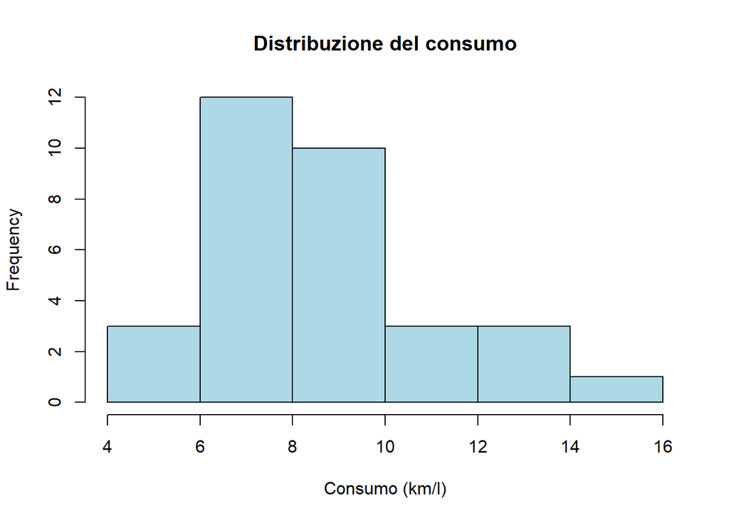

```r
# Istogramma del consumo
hist(mtcars_it$consumo,
     main = "Distribuzione del consumo",
     xlab = "Consumo (km/l)",
     col = "lightblue")
```

### 🔹 2) Istogramma del peso con densità

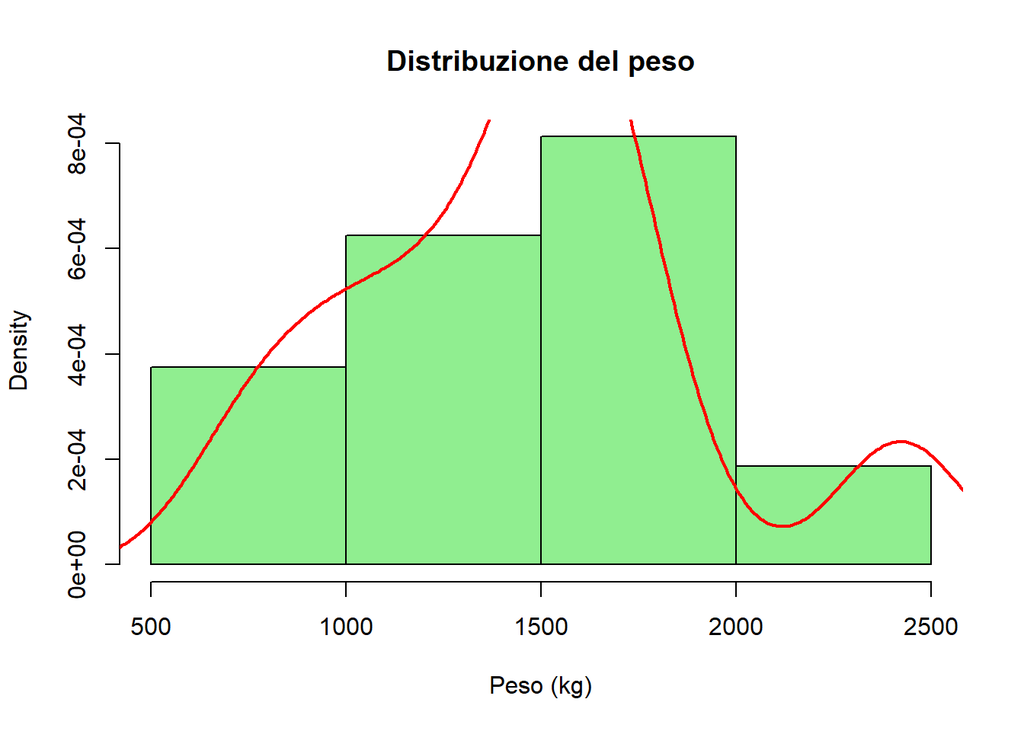

```r
# Istogramma del peso
hist(mtcars_it$peso,
     main = "Distribuzione del peso",
     xlab = "Peso (kg)",
     col = "lightgreen",
     probability = TRUE)

# Aggiungo la curva di densità
lines(density(mtcars_it$peso), col = "red", lwd = 2)
```

### 🔹 3) Boxplot del consumo per cilindri

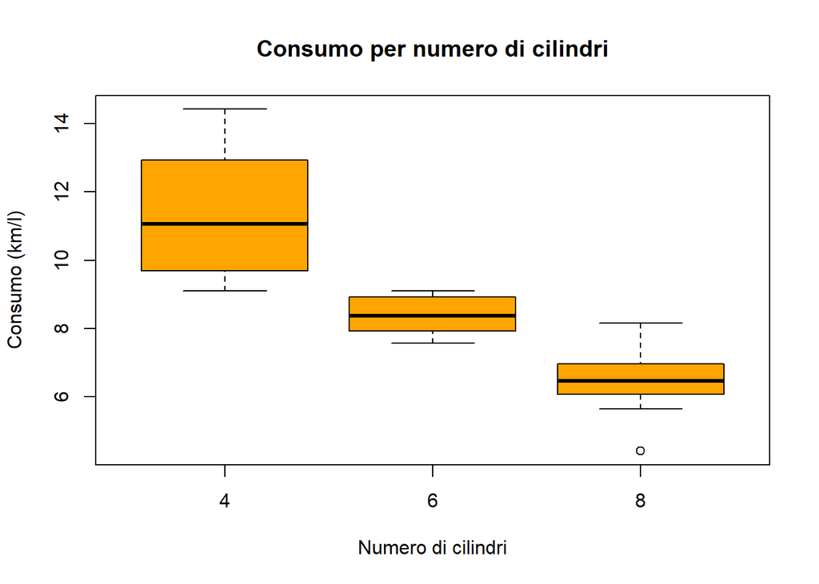

```r
# Boxplot del consumo rispetto ai cilindri
boxplot(consumo ~ cyl,
        data = mtcars_it,
        main = "Consumo per numero di cilindri",
        xlab = "Numero di cilindri",
        ylab = "Consumo (km/l)",
        col = "orange")
```

# 2. Esercizio con Dataset

Caricare il dataset `Sport` (presente sia in formato `.csv` che `.RData`), poi:

## Parte A: esplorazione del dataset

1. Esplorare il dataset: quante osservazioni e quante variabili contiene? Quali variabili sono numeriche e quali categoriali? Ci sono valori mancanti?

Rispondere alle seguenti domande:

1. Qual è il numero medio di passi giornalieri nel dataset?
2. Qual è la frequenza cardiaca a riposo media dei soggetti che si allenano almeno tre volte alla settimana?
3. Qual è lo sport con il maggior numero di passi medi giornalieri?
4. Possiamo dire che gli individui che praticano corsa hanno una frequenza cardiaca media a riposo più bassa rispetto ad altri sport?
5. Considerando solo gli individui con più di 8000 passi giornalieri, qual è la frequenza cardiaca media a riposo per ciascun tipo di sport?
6. Se si esclude l’individuo con il numero massimo di passi giornalieri, come cambia la media dei passi giornalieri nel dataset?
7. Se definiamo una nuova variabile chiamata `indice_salute`, definita come il rapporto tra passi giornalieri e frequenza cardiaca a riposo, quali sono i tre individui con il valore più alto di questo indice? Che sport praticano?
8. Possiamo affermare che gli individui che si allenano più frequentemente tendono ad avere una frequenza cardiaca a riposo più bassa?
9. Costruire le tabelle di frequenza assoluta e relativa della variabile `sport`; qual è lo sport più praticato?
10. Creare una variabile che distingua tra colore che si allenano almeno 3 giorni alla settimana e coloro che si allenano meno frequentemente, poi costruire una tabella a doppia entrata tra questa nuova variabile e `sport`. Calcolare poi le frequenze relative e commentare se lo sport praticato sembra associato alla frequenza di allenamento.

## ✏️ Svolgimento

### 🔹 1) Esplorazione del dataset

```r
# Carico il dataset
Sport <- read.csv("Sport.csv")

# Prime righe
head(Sport)
```

```
##      sport giorni_allenamento ore_sonno passi_giornalieri calorie_giornaliere
## 1 palestra                  1       6.8              4134                2538
## 2     yoga                  2       7.3              7785                2394
## 3 palestra                  5       6.5             13630                 650
## 4    corsa                  3       7.9              9679                2488
## 5    corsa                  5       6.3             13173                3026
## 6  nessuno                  0       8.8             42012                1744
##   frequenza_cardiaca_riposo
## 1                        76
## 2                        72
## 3                        62
## 4                        67
## 5                        62
## 6                        69
```

```r
# Struttura
str(Sport)
```

```
## 'data.frame':    50 obs. of  6 variables:
##  $ sport                    : chr  "palestra" "yoga" "palestra" "corsa" ...
##  $ giorni_allenamento       : int  1 2 5 3 5 0 1 6 5 3 ...
##  $ ore_sonno                : num  6.8 7.3 6.5 7.9 6.3 8.8 5 7.1 6.6 NA ...
##  $ passi_giornalieri        : int  4134 7785 13630 9679 13173 42012 4023 14298 13430 10978 ...
##  $ calorie_giornaliere      : int  2538 2394 650 2488 3026 1744 2593 3156 3395 2665 ...
##  $ frequenza_cardiaca_riposo: int  76 72 62 67 62 69 68 59 68 66 ...
```

```r
# Statistiche
summary(Sport)
```

```
##     sport           giorni_allenamento   ore_sonno      passi_giornalieri
##  Length:50          Min.   :0.00       Min.   : 2.800   Min.   :  -80
##  Class :character   1st Qu.:2.00       1st Qu.: 6.200   1st Qu.: 5672
##  Mode  :character   Median :3.00       Median : 6.800   Median : 8471
##                     Mean   :2.98       Mean   : 6.967   Mean   : 9835
##                     3rd Qu.:5.00       3rd Qu.: 7.700   3rd Qu.:13366
##                     Max.   :6.00       Max.   :14.000   Max.   :42012
##                                        NA's   :5
##  calorie_giornaliere frequenza_cardiaca_riposo
##  Min.   : 650        Min.   : 50.00
##  1st Qu.:2264        1st Qu.: 62.00
##  Median :2665        Median : 67.00
##  Mean   :2621        Mean   : 67.86
##  3rd Qu.:3068        3rd Qu.: 69.00
##  Max.   :5023        Max.   :118.00
##  NA's   :3
```

```r
# Numero osservazioni e variabili
dim(Sport)
```

```
## [1] 50  6
```

```r
# Controllo valori mancanti
colSums(is.na(Sport))
```

```
##                     sport        giorni_allenamento                 ore_sonno
##                         0                         0                         5
##         passi_giornalieri       calorie_giornaliere frequenza_cardiaca_riposo
##                         0                         3                         0
```

## 💥 RISPOSTA:

Il dataset contiene:

- **50 osservazioni** e **6 variabili**

👉 Variabili:

- **sport** → categoriale (character)
- **giorni_allenamento** → numerica (intera)
- **ore_sonno** → numerica (continua)
- **passi_giornalieri** → numerica (intera)
- **calorie_giornaliere** → numerica (intera)
- **frequenza_cardiaca_riposo** → numerica (intera)

👉 Valori mancanti:

- **ore_sonno** → 5 valori mancanti
- **calorie_giornaliere** → 3 valori mancanti

💥 Il dataset presenta quindi alcuni valori mancanti da considerare nelle analisi

### 🔹 Domande (a, b, c):

```r
# a) Media passi giornalieri
mean(Sport$passi_giornalieri)
```

```
## [1] 9834.84
```

```r
# b) Frequenza cardiaca media (almeno 3 allenamenti)
Sport %>%
  filter(giorni_allenamento >= 3) %>%
  summarise(media_fc = mean(frequenza_cardiaca_riposo))
```

```
##   media_fc
## 1 65.62963
```

```r
# c) Sport con più passi medi
Sport %>%
  group_by(sport) %>%
  summarise(passi_medi = mean(passi_giornalieri)) %>%
  arrange(desc(passi_medi))
```

```
## # A tibble: 5 × 2
##   sport    passi_medi
##   <chr>         <dbl>
## 1 corsa        12328.
## 2 palestra     11266.
## 3 yoga          8746.
## 4 nuoto         8628.
## 5 nessuno       7367.
```

## 💥 Risposte

a): Il numero medio di passi giornalieri è pari a **9834.84**.

b): La frequenza cardiaca media a riposo dei soggetti che si allenano almeno 3 volte a settimana è pari a **65.63 bpm**.

c): Lo sport con il maggior numero medio di passi giornalieri è la **corsa**.

### 🔹 Domande (d, e, f):

```r
# d) Frequenza cardiaca media per sport
Sport %>%
  group_by(sport) %>%
  summarise(fc_media = mean(frequenza_cardiaca_riposo))
```

```
## # A tibble: 5 × 2
##   sport    fc_media
##   <chr>       <dbl>
## 1 corsa        68.5
## 2 nessuno      68.5
## 3 nuoto        72.6
## 4 palestra     63.7
## 5 yoga         65.8
```

```r
# e) Frequenza cardiaca media per sport (solo passi > 8000)
Sport %>%
  filter(passi_giornalieri > 8000) %>%
  group_by(sport) %>%
  summarise(fc_media = mean(frequenza_cardiaca_riposo))
```

```
## # A tibble: 5 × 2
##   sport    fc_media
##   <chr>       <dbl>
## 1 corsa        68.2
## 2 nessuno      67.7
## 3 nuoto        67
## 4 palestra     61.9
## 5 yoga         61
```

```r
# f) Media passi senza il massimo
mean(Sport$passi_giornalieri[Sport$passi_giornalieri != max(Sport$passi_giornalieri)])
```

```
## [1] 9178.163
```

## 💥 Risposte

d): La frequenza cardiaca media varia tra gli sport; i valori più bassi si osservano per **palestra** e **yoga**, mentre i più alti per **nuoto** e **corsa**.

e): Considerando solo chi supera 8000 passi, la frequenza cardiaca media tende a diminuire, con valori più bassi per **yoga** e **palestra**.

f): Escludendo il valore massimo, la media dei passi scende a **9178.16**, indicando la presenza di un outlier. .

### 🔹 Domanda g:

```r
# Creo indice_salute
Sport <- Sport %>%
  mutate(indice_salute = passi_giornalieri / frequenza_cardiaca_riposo)

# Prendo i 3 individui con valore più alto
Sport %>%
  arrange(desc(indice_salute)) %>%
  head(3)
```

```
##      sport giorni_allenamento ore_sonno passi_giornalieri calorie_giornaliere
## 1  nessuno                  0       8.8             42012                1744
## 2 palestra                  6       6.2             19064                3431
## 3    corsa                  6       6.9             17477                3483
##   frequenza_cardiaca_riposo indice_salute
## 1                        69      608.8696
## 2                        62      307.4839
## 3                        60      291.2833
```

## 💥 Risposta

g): I tre individui con il valore più alto dell’indice di salute praticano **nessuno**, **palestra** e **corsa**.

### 🔹 Domande (h, i, j):

```r
# h) Relazione tra allenamento e frequenza cardiaca
Sport %>%
  group_by(giorni_allenamento) %>%
  summarise(fc_media = mean(frequenza_cardiaca_riposo))
```

```
## # A tibble: 7 × 2
##   giorni_allenamento fc_media
##                <int>    <dbl>
## 1                  0     70
## 2                  1     71.2
## 3                  2     70.5
## 4                  3     67
## 5                  4     65
## 6                  5     68.4
## 7                  6     60
```

```r
# i) Frequenza assoluta e relativa dello sport
freq_sport <- table(Sport$sport)
freq_sport
```

```
##
##    corsa  nessuno    nuoto palestra     yoga
##       11       12       10       13        4
```

```r
prop.table(freq_sport)
```

```
##
##    corsa  nessuno    nuoto palestra     yoga
##     0.22     0.24     0.20     0.26     0.08
```

```r
# j) Nuova variabile (>=3 allenamenti) e tabella
Sport <- Sport %>%
  mutate(allenamento_freq = ifelse(giorni_allenamento >= 3, "alto", "basso"))

tabella <- table(Sport$allenamento_freq, Sport$sport)
tabella
```

```
##
##         corsa nessuno nuoto palestra yoga
##   alto     10       0     5       10    2
##   basso     1      12     5        3    2
```

```r
prop.table(tabella, margin = 1)
```

```
##
##              corsa    nessuno      nuoto   palestra       yoga
##   alto  0.37037037 0.00000000 0.18518519 0.37037037 0.07407407
##   basso 0.04347826 0.52173913 0.21739130 0.13043478 0.08695652
```

## 💥 Risposte

h): Aumentando i giorni di allenamento, la frequenza cardiaca media tende a diminuire.

i): Lo sport più praticato è la **palestra (26%)**, seguito da **nessuno (24%)** e **corsa (22%)**.

j): Gli individui con allenamento alto praticano soprattutto **corsa** e **palestra**, mentre quelli con allenamento basso sono prevalentemente nel gruppo **nessuno**.

## Parte B: descrizione grafica

1. Costruire un istogramma della variabile `passi_giornalieri` e commentare l’eventuale presenza di valori anomali;
2. Costruire un boxplot della frequenza cardiaca a riposo per sport; dal boxplot, possiamo osservare se ci siano differenze sulla frequenza cardiaca a seconda dello sport?

## 📌 Parte B — Descrizione grafica

### 🔹 1) Istogramma dei passi giornalieri

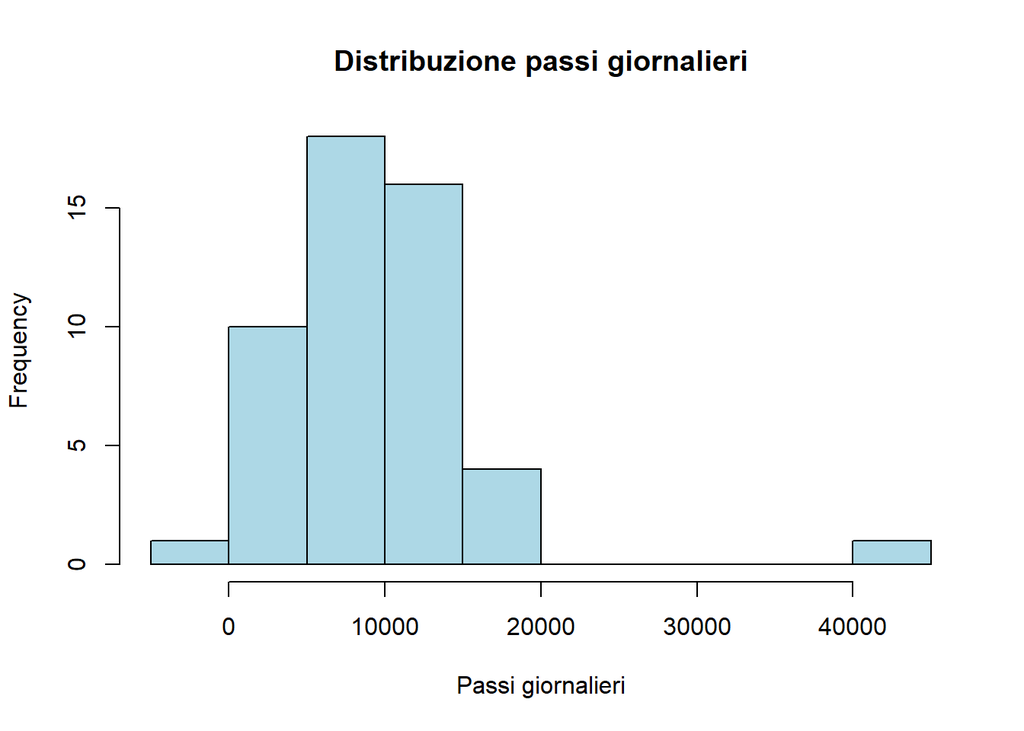

```r
hist(Sport$passi_giornalieri,
     main = "Distribuzione passi giornalieri",
     xlab = "Passi giornalieri",
     col = "lightblue")
```

## 💥 Risposta

La distribuzione dei passi giornalieri mostra valori molto elevati rispetto agli altri, suggerendo la presenza di possibili **outlier**.

### 🔹 2) Boxplot frequenza cardiaca per sport

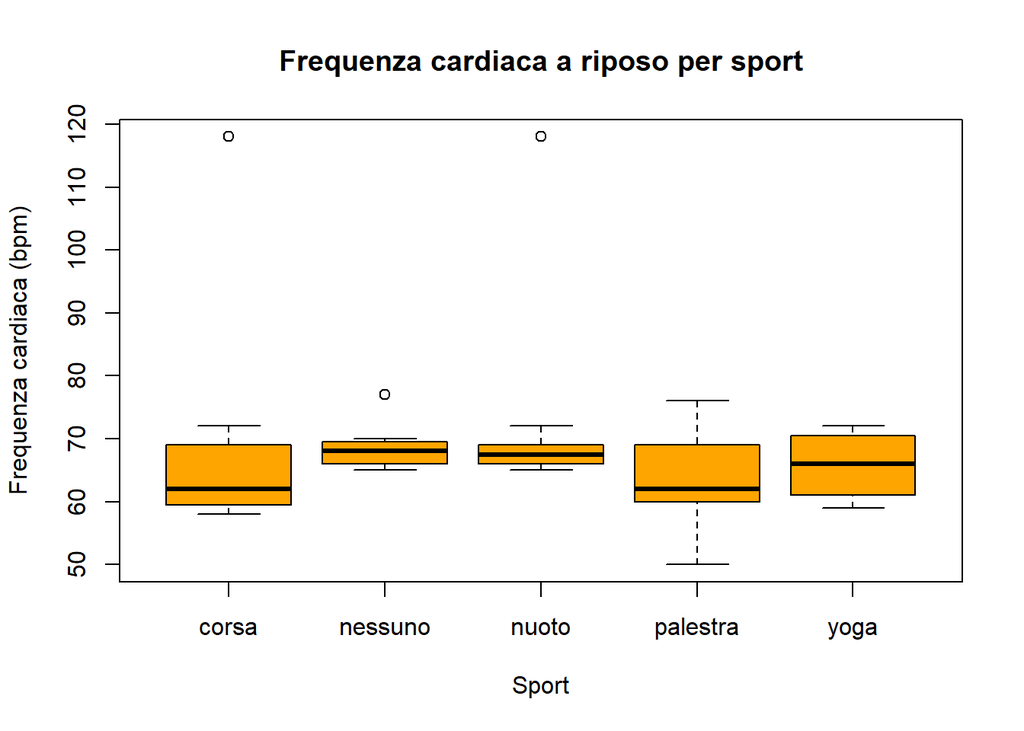

```r
boxplot(frequenza_cardiaca_riposo ~ sport,
        data = Sport,
        main = "Frequenza cardiaca a riposo per sport",
        xlab = "Sport",
        ylab = "Frequenza cardiaca (bpm)",
        col = "orange")
```